# Covid 19 testing

Introduction:

We are all aware of the circumstances present at this time: non-essential workers are stuck working from home, students around the world have been sent home and are forced to study online, and the US economy is seeing its worst days since the Great Depression. These are facts of the matter and it is now up to us to determine what comes next. What questions should we be asking? What are we trying to achieve? How do we determine what is a success?

Discussion:

One answer to these questions may come down to the number of tests allocated to countries. Right now, there is no country that has as many tests as they do population. That creates some trouble when trying to figure out who actually has the virus because we can’t confirm whether people do have the virus. Also, all data on the virus is based around “confirmed cases” which the World Health Organization defines as positive tests performed in a laboratory setting. This number is presumably much lower than the actual number of confirmed cases since (1) the virus is asymptomatic for about 2 weeks and (2) we don’t have enough tests to allocate a test for every citizen and likely won’t have the resources to make 7.8 billion by the time the virus has stopped spreading. The number of tests as well as the rate of false negatives and positives can be a very useful tool in determining how well the spread of the virus is progressing. The question I will be asking is as follows: Using the number of tests and success rate of those tests, can we determine the predicted number of positive cases is a country? From there, can we say if there is a relationship between the number of tests available to a country and the number of positive covid-19 cases.

```r
summary(covid)
```

```
##  Country or region      Date               Tests          Positive
##  Length:127         Length:127         Min.   : 37.0   Min.   :     0.0
##  Class :character   Class :character   1st Qu.:397.0   1st Qu.:   524.5
##  Mode  :character   Mode  :character   Median :518.5   Median :  2651.0
##                                        Mean   :499.5   Mean   : 19149.3
##                                        3rd Qu.:680.5   3rd Qu.: 10661.5
##                                        Max.   :832.0   Max.   :605243.0
##                                        NA's   :121     NA's   :1
##        %          Tests /millionpeople Positive /millionpeople
##  Min.   : 0.000   Min.   :   24        Min.   :    0.00
##  1st Qu.: 2.325   1st Qu.: 2118        1st Qu.:   98.25
##  Median : 7.750   Median : 8444        Median :  308.50
##  Mean   : 9.777   Mean   :10720        Mean   :  937.48
##  3rd Qu.:12.700   3rd Qu.:15903        3rd Qu.: 1109.50
##  Max.   :49.200   Max.   :99761        Max.   :10394.00
##  NA's   :1        NA's   :1            NA's   :1
##      Ref.             Source_1           Source_2
##  Length:127         Length:127         Length:127
##  Class :character   Class :character   Class :character
##  Mode  :character   Mode  :character   Mode  :character
##
##
##
##
```

```r
glimpse(covid)
```

```
## Observations: 127
## Variables: 10
## $ `Country or region`       <chr> "Albania", "Argentina", "Armenia", "Au…
## $ Date                      <chr> "15 Apr", "11 Apr", "11 Apr", "15 Apr"…
## $ Tests                     <dbl> NA, NA, NA, NA, NA, NA, NA, NA, NA, NA…
## $ Positive                  <dbl> 494, 2142, 967, 6449, 103, 2886, 28, 9…
## $ `%`                       <dbl> 10.8, 11.9, 14.9, 1.7, 1.6, 2.0, 0.8, …
## $ `Tests /millionpeople`    <dbl> 1592, 400, 2197, 14621, 15209, 18186, …
## $ `Positive /millionpeople` <dbl> 173.0, 48.0, 328.0, 254.0, 241.0, 357.…
## $ Ref.                      <chr> "cite_note-100", "cite_note-101", "cit…
## $ Source_1                  <chr> "https://shendetesia.gov.al/covid-19-m…
## $ Source_2                  <chr> NA, NA, NA, NA, NA, NA, NA, NA, NA, NA…
```

```r
glimpse(world_pop)
```

```
## Observations: 227
## Variables: 20
## $ Country                              <chr> "Afghanistan", "Albania", "…
## $ Region                               <chr> "ASIA (EX. NEAR EAST)", "EA…
## $ Population                           <dbl> 31056997, 3581655, 32930091…
## $ `Area (sq. mi.)`                     <dbl> 647500, 28748, 2381740, 199…
## $ `Pop. Density (per sq. mi.)`         <chr> "48,0", "124,6", "13,8", "2…
## $ `Coastline (coast/area ratio)`       <chr> "0,00", "1,26", "0,04", "58…
## $ `Net migration`                      <chr> "23,06", "-4,93", "-0,39", …
## $ `Infant mortality (per 1000 births)` <dbl> 16307, 2152, 31, 927, 405, …
## $ `GDP ($ per capita)`                 <dbl> 700, 4500, 6000, 8000, 1900…
## $ `Literacy (%)`                       <dbl> 360, 865, 700, 970, 1000, 4…
## $ `Phones (per 1000)`                  <chr> "3,2", "71,2", "78,1", "259…
## $ `Arable (%)`                         <chr> "12,13", "21,09", "3,22", "…
## $ `Crops (%)`                          <chr> "0,22", "4,42", "0,25", "15…
## $ `Other (%)`                          <dbl> 8765, 7449, 9653, 75, 9778,…
## $ Climate                              <dbl> 1, 3, 1, 2, 3, NA, 2, 2, 3,…
## $ Birthrate                            <dbl> 466, 1511, 1714, 2246, 871,…
## $ Deathrate                            <dbl> 2034, 522, 461, 327, 625, 2…
## $ Agriculture                          <chr> "0,38", "232", "101", NA, N…
## $ Industry                             <chr> "0,24", "188", "0,6", NA, N…
## $ Service                              <chr> "0,38", "579", "298", NA, N…
```

From the Date column we can see that this dataset was updated on April 15 so it won’t be as up to date as we might’ve liked, but still a fairly recent dataset. We will want to mostly use data per million population becuase they will give us more uniform values between different countries.

```r
clean_covid <- covid %>%
  select(`Country or region`, Positive, `%`, `Tests /millionpeople`, `Positive /millionpeople`) %>%
  filter(`Country or region` != 'China') %>% #Removing China since it is only a row of NA's. Could be due to their lack of transparency with testing, etc.
  rename(Country = `Country or region`) #renaming the country column to match the population name


population <- world_pop %>%
  select(Country, Population) #selecting only the country and population from the world_pop dataset

summary(clean_covid)
```

```
##    Country             Positive              %
##  Length:126         Min.   :     0.0   Min.   : 0.000
##  Class :character   1st Qu.:   524.5   1st Qu.: 2.325
##  Mode  :character   Median :  2651.0   Median : 7.750
##                     Mean   : 19149.3   Mean   : 9.777
##                     3rd Qu.: 10661.5   3rd Qu.:12.700
##                     Max.   :605243.0   Max.   :49.200
##  Tests /millionpeople Positive /millionpeople
##  Min.   :   24        Min.   :    0.00
##  1st Qu.: 2118        1st Qu.:   98.25
##  Median : 8444        Median :  308.50
##  Mean   :10720        Mean   :  937.48
##  3rd Qu.:15903        3rd Qu.: 1109.50
##  Max.   :99761        Max.   :10394.00
```

```r
summary(population)
```

```
##    Country            Population
##  Length:227         Min.   :7.026e+03
##  Class :character   1st Qu.:4.376e+05
##  Mode  :character   Median :4.787e+06
##                     Mean   :2.874e+07
##                     3rd Qu.:1.750e+07
##                     Max.   :1.314e+09
```

```r
df <- merge(clean_covid, population, by = 'Country') #creating one dataset of covid data and population by country

summary(df)
```

```
##    Country             Positive            %         Tests /millionpeople
##  Length:77          Min.   :    10   Min.   : 0.20   Min.   :   24
##  Class :character   1st Qu.:   926   1st Qu.: 3.40   1st Qu.:  865
##  Mode  :character   Median :  2919   Median : 8.00   Median : 3857
##                     Mean   : 23380   Mean   : 9.57   Mean   : 9147
##                     3rd Qu.: 10303   3rd Qu.:12.70   3rd Qu.:12952
##                     Max.   :605243   Max.   :31.40   Max.   :99761
##  Positive /millionpeople   Population
##  Min.   :   0.6          Min.   :8.970e+04
##  1st Qu.:  58.0          1st Qu.:4.495e+06
##  Median : 254.0          Median :1.069e+07
##  Mean   : 638.2          Mean   :5.311e+07
##  3rd Qu.: 814.0          3rd Qu.:5.813e+07
##  Max.   :4722.0          Max.   :1.095e+09
```

It is worth noting that the population data that I am using is from 2018. Since then the world population has increased from 7.6E+09 to 7.8E+09. ((7.8E+09 - 7.6E+09) * 100)/(7.6E+09) = 2.63%. If we assume that this rate is uniform accross all countries we can apply that to these popluations to get a better estimate of where we are at currently.

```r
df <- df %>%
  mutate(Population2020 = (df$Population*1.0263))

glimpse(df$Population)
```

```
##  num [1:77] 3581655 39921833 2976372 20264082 8192880 ...
```

```r
glimpse(df$Population2020)
```

```
##  num [1:77] 3675853 40971777 3054651 20797027 8408353 ...
```

```r
df <- df %>%
  select(-Population) %>%
  rename(Population = Population2020)

glimpse(df$Population)
```

```
##  num [1:77] 3675853 40971777 3054651 20797027 8408353 ...
```

Now that we have the updated population we are able to proceed with analysis.

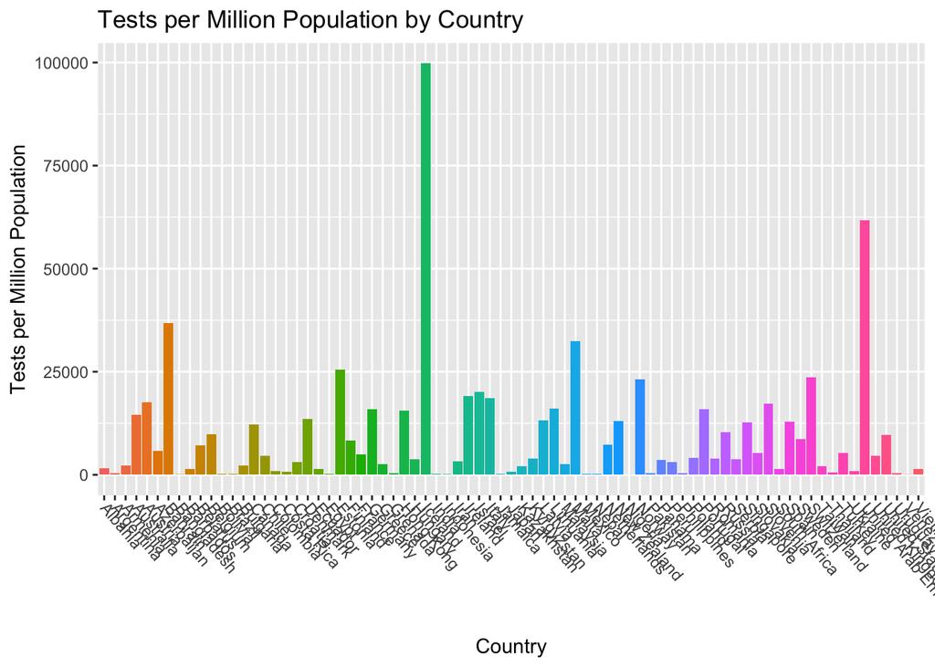

```r
df %>%
  ggplot(aes(x = `Country`, y = `Tests /millionpeople`, fill = `Country`)) +
  stat_summary(fun.y = "mean", geom = "bar") +
  stat_summary(fun.data = "mean_cl_normal", geom = "errorbar", fun.args = list(conf.int = .95), width = 0.35) +
  theme(legend.position = "none") +
  labs(x = "Country", y = "Tests per Million Population", title = "Tests per Million Population by Country") +
theme(axis.text.x = element_text(angle = -50, hjust = 0, vjust = 0.5))
```

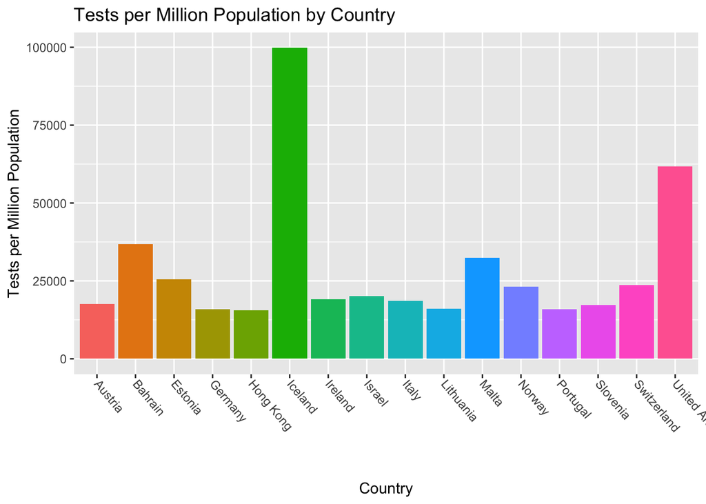

```r
df1 <- df %>%
  filter(`Tests /millionpeople` > 15000)

df1 %>%
  ggplot(aes(x = `Country`, y = `Tests /millionpeople`, fill = `Country`)) +
  stat_summary(fun.y = "mean", geom = "bar") +
  stat_summary(fun.data = "mean_cl_normal", geom = "errorbar", fun.args = list(conf.int = .95), width = 0.35) +
  theme(legend.position = "none") +
  labs(x = "Country", y = "Tests per Million Population", title = "Tests per Million Population by Country") +
theme(axis.text.x = element_text(angle = -50, hjust = 0, vjust = 0.5))
```

```r
summary(df1)
```

```
##    Country             Positive            %          Tests /millionpeople
##  Length:16          Min.   :   370   Min.   : 0.450   Min.   :15539
##  Class :character   1st Qu.:  1196   1st Qu.: 2.375   1st Qu.:16872
##  Mode  :character   Median :  4490   Median : 4.900   Median :19541
##                     Mean   : 22736   Mean   : 6.185   Mean   :28675
##                     3rd Qu.: 14935   3rd Qu.: 9.400   3rd Qu.:27291
##                     Max.   :165155   Max.   :14.800   Max.   :99761
##  Positive /millionpeople   Population
##  Min.   : 125.0          Min.   :  307262
##  1st Qu.: 588.8          1st Qu.: 1887205
##  Median :1195.0          Median : 4450578
##  Mean   :1479.4          Mean   :12813714
##  3rd Qu.:1838.8          3rd Qu.: 7893448
##  Max.   :4722.0          Max.   :84590005
```

```r
mean(df$`Tests /millionpeople`)
```

```
## [1] 9146.935
```

So, from this graph we can see that, at best, a country only has tests for 10% of it’s population. Even then, countries with tests for more than 1.5% of it’s population have an median population of only 4,450,578, much less than the population of even Ohio. The for all countries an average of only about 1% of the population can be tested. This figure seems staggeringly low. We have only produced enough tests for 1% of the worlds population? Currently there is a total of 2,500,000 confirmed cases meaning that about 0.03% of the worlds population have confirmed cases.

```r
df <- df %>%
  mutate(rate = (`Positive /millionpeople`/`Tests /millionpeople`)) %>%
  mutate(cases = rate*Population)

mean(df$rate)*100
```

```
## [1] 9.600971
```

```r
sum(df$Positive) - sum(df$cases)
```

```
## [1] -401003207
```

We can tell from this that the average percentage of tests that give a positive result is about 10%. Using this rate of positive cases we can find the expected number of cases if we had the means of testing the whole population. This gives us a value of 401,003,207, 5.14% of the world population, a difference of 5.11%.

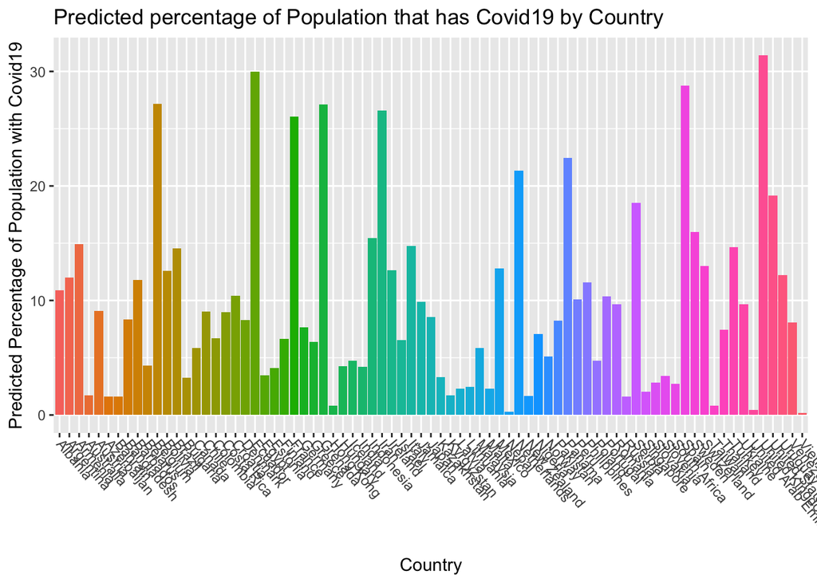

```r
df <- df %>%
  mutate(percentage = (cases/Population)*100)

df %>%
  ggplot(aes(x = `Country`, y = percentage, fill = `Country`)) +
  stat_summary(fun.y = "mean", geom = "bar") +
  stat_summary(fun.data = "mean_cl_normal", geom = "errorbar", fun.args = list(conf.int = .95), width = 0.35) +
  theme(legend.position = "none") +
  labs(x = "Country", y = "Predicted Percentage of Population with Covid19", title = "Predicted percentage of Population that has Covid19 by Country") +
theme(axis.text.x = element_text(angle = -50, hjust = 0, vjust = 0.5))
```

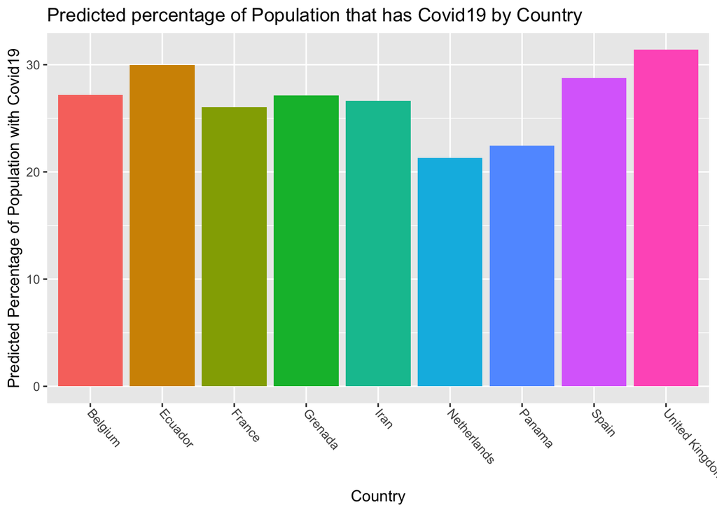

```r
df2 <- df %>%
  filter(percentage > 20)

df2 %>%
  ggplot(aes(x = `Country`, y = percentage, fill = `Country`)) +
  stat_summary(fun.y = "mean", geom = "bar") +
  stat_summary(fun.data = "mean_cl_normal", geom = "errorbar", fun.args = list(conf.int = .95), width = 0.35) +
  theme(legend.position = "none") +
  labs(x = "Country", y = "Predicted Percentage of Population with Covid19", title = "Predicted percentage of Population that has Covid19 by Country") +
theme(axis.text.x = element_text(angle = -50, hjust = 0, vjust = 0.5))
```

geom_point() tests/million vs. predicted cases/million

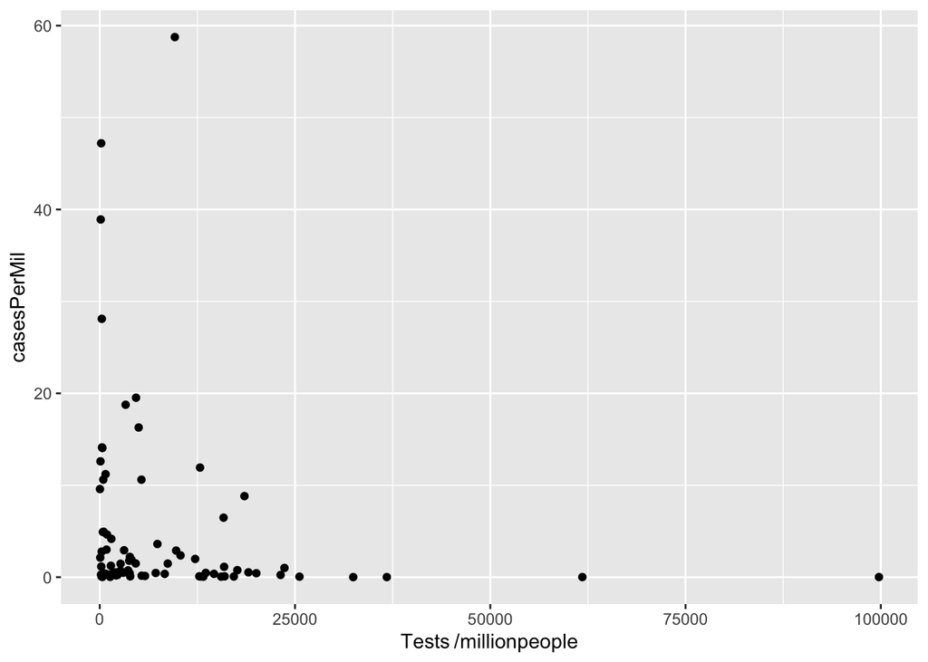

```r
df3 <- df %>%
  mutate(casesPerMil = cases/1000000)

df4 <- df2 %>%
  mutate(casesPerMil = cases/1000000)

df3 %>%
  ggplot(aes(x = `Tests /millionpeople`, y = casesPerMil)) +
  geom_point()
```

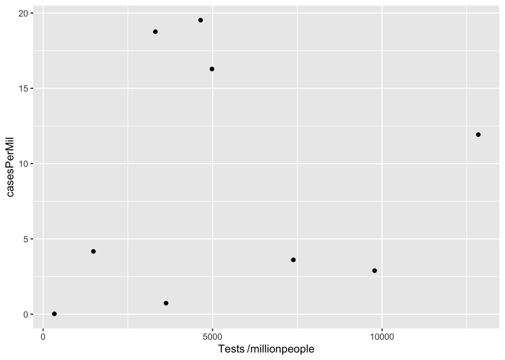

```r
df4 %>%
  ggplot(aes(x = `Tests /millionpeople`, y = casesPerMil)) +
  geom_point()
```

```r
df5 <- df3 %>%
  filter(`Tests /millionpeople` > 75000)

glimpse(df5)
```

```
## Observations: 1
## Variables: 10
## $ Country                   <chr> "Iceland"
## $ Positive                  <dbl> 1720
## $ `%`                       <dbl> 4.7
## $ `Tests /millionpeople`    <dbl> 99761
## $ `Positive /millionpeople` <dbl> 4722
## $ Population                <dbl> 307261.9
## $ rate                      <dbl> 0.04733313
## $ cases                     <dbl> 14543.67
## $ percentage                <dbl> 4.733313
## $ casesPerMil               <dbl> 0.01454367
```

```r
df6 <- df3 %>%
  filter(casesPerMil > 40)

glimpse(df6)
```

```
## Observations: 2
## Variables: 10
## $ Country                   <chr> "India", "United States"
## $ Positive                  <dbl> 10307, 605243
## $ `%`                       <dbl> 4.5, 19.2
## $ `Tests /millionpeople`    <dbl> 181, 9613
## $ `Positive /millionpeople` <dbl> 7.6, 1844.0
## $ Population                <dbl> 1124159752, 306293298
## $ rate                      <dbl> 0.04198895, 0.19182357
## $ cases                     <dbl> 47202288, 58754275
## $ percentage                <dbl> 4.198895, 19.182357
## $ casesPerMil               <dbl> 47.20229, 58.75427
```

```r
covidREG <- lm(casesPerMil ~ `Tests /millionpeople`, df3)
summary(covidREG)
```

```
##
## Call:
## lm(formula = casesPerMil ~ `Tests /millionpeople`, data = df3)
##
## Residuals:
##    Min     1Q Median     3Q    Max
## -6.324 -5.196 -3.574 -1.393 53.582
##
## Coefficients:
##                          Estimate Std. Error t value Pr(>|t|)
## (Intercept)             6.391e+00  1.395e+00   4.582  1.8e-05 ***
## `Tests /millionpeople` -1.268e-04  8.119e-05  -1.562    0.123
## ---
## Signif. codes:  0 '***' 0.001 '**' 0.01 '*' 0.05 '.' 0.1 ' ' 1
##
## Residual standard error: 10.36 on 75 degrees of freedom
## Multiple R-squared:  0.03149,    Adjusted R-squared:  0.01858
## F-statistic: 2.439 on 1 and 75 DF,  p-value: 0.1226
```

```r
covidREG2 <- lm(casesPerMil ~ `Tests /millionpeople`, df4)
summary(covidREG2)
```

```
##
## Call:
## lm(formula = casesPerMil ~ `Tests /millionpeople`, data = df4)
##
## Residuals:
##    Min     1Q Median     3Q    Max
## -7.485 -6.865 -3.516  7.722 11.050
##
## Coefficients:
##                         Estimate Std. Error t value Pr(>|t|)
## (Intercept)            7.3141178  4.8944495   1.494    0.179
## `Tests /millionpeople` 0.0002499  0.0007456   0.335    0.747
##
## Residual standard error: 8.427 on 7 degrees of freedom
## Multiple R-squared:  0.01579,    Adjusted R-squared:  -0.1248
## F-statistic: 0.1123 on 1 and 7 DF,  p-value: 0.7473
```

```r
covidREG1 <- lm(`Positive /millionpeople` ~ `Tests /millionpeople`, df)
summary(covidREG1)
```

```
##
## Call:
## lm(formula = `Positive /millionpeople` ~ `Tests /millionpeople`,
##     data = df)
##
## Residuals:
##     Min      1Q  Median      3Q     Max
## -2383.4  -294.8  -250.4   256.1  2912.0
##
## Coefficients:
##                         Estimate Std. Error t value Pr(>|t|)
## (Intercept)            2.868e+02  9.899e+01   2.897  0.00493 **
## `Tests /millionpeople` 3.842e-02  5.762e-03   6.667 3.88e-09 ***
## ---
## Signif. codes:  0 '***' 0.001 '**' 0.01 '*' 0.05 '.' 0.1 ' ' 1
##
## Residual standard error: 735.3 on 75 degrees of freedom
## Multiple R-squared:  0.3721, Adjusted R-squared:  0.3637
## F-statistic: 44.45 on 1 and 75 DF,  p-value: 3.885e-09
```

We can’t be sure whether more testing in countries that already have a high number of people infected would decrease the prediction, but I would still advise the implementation of more testing across the country. If we can find out who has been infected, it will be easier to have those infected quarantine themselves. Research on a vaccine for covid-19 is undoubtedly an important part in the measures being taken, however, focusing more effort into the production of tests will be more useful in the long run. The earlier we can test most of the population, the earlier those not infected can begin to come back to society as we once knew. Those who are not tested however should remain in quarantine. Moreover, even if you have been tested, the safest thing to do is stay home. You never know who you could come into contact with and whether themselves or someone they’ve been in contact with are infected. If you have been tested and come back negative, interacting with others who have not been tested will do nothing but cause uncertainty in the test result. You now would have no idea if you are infected or not. Ultimately, until we have enough tests to test a large part of our population, we should keep stay-at-home orders in effect.